# Graphics

Цель: Составить графики, проанализировать их и провести кластеризацию.

```python
import pandas as pd
import numpy as np

# библиотека для построения графиков
import seaborn as sns
# библиотека с упрощенными графиками
import matplotlib.pyplot as plot
```

Подключаем библиотеки из прошлой работы, а так же добавляем две новые библиотеки, одну из них устанавливаем через терминал. Далее выгружаем набр данных из файла.

```python
#считывание данных с файла
df = pd.read_csv('vgsales_19.csv')
df
```

|  | Rank | Name | Platform | Year | Genre | Publisher | NA_Sales | EU_Sales | JP_Sales | Other_Sales | Global_Sales |
| --- | --- | --- | --- | --- | --- | --- | --- | --- | --- | --- | --- |
| 0 | 7164 | Discovery Kids: Dolphin Discovery | DS | 2008.0 | Simulation | 505 Games | 0.21 | 0.00 | 0.00 | 0.01 | 0.22 |
| 1 | 15834 | LifeSigns: Surgical Unit | DS | 2005.0 | Simulation | JoWood Productions | 0.01 | 0.01 | 0.00 | 0.00 | 0.02 |
| 2 | 11539 | Sengoku Musou 3: Moushouden | Wii | 2011.0 | Action | Ackkstudios | 0.00 | 0.00 | 0.08 | 0.00 | 0.08 |
| 3 | 593 | LittleBigPlanet | PSP | 2009.0 | Platform | Sony Computer Entertainment | 0.64 | 1.24 | 0.01 | 0.69 | 2.58 |
| 4 | 12211 | Yoake Yori Ruriiro na: Brighter than Dawning Blue | PS2 | 2006.0 | Adventure | Aria | 0.00 | 0.00 | 0.07 | 0.00 | 0.07 |
| ... | ... | ... | ... | ... | ... | ... | ... | ... | ... | ... | ... |
| 548 | 4537 | Castlevania: Portrait of Ruin | DS | 2006.0 | Platform | Konami Digital Entertainment | 0.33 | 0.03 | 0.04 | 0.03 | 0.43 |
| 549 | 11524 | Puzzler Mind Gym 3D | 3DS | 2011.0 | Puzzle | Ubisoft | 0.07 | 0.00 | 0.00 | 0.00 | 0.08 |
| 550 | 1366 | Inazuma Eleven 2 | DS | 2009.0 | Role-Playing | Nintendo | 0.00 | 0.21 | 1.18 | 0.03 | 1.42 |
| 551 | 4135 | Tomb Raider: Underworld | Wii | 2008.0 | Action | Eidos Interactive | 0.14 | 0.28 | 0.00 | 0.06 | 0.48 |
| 552 | 3828 | GT Pro Series | Wii | 2006.0 | Racing | Ubisoft | 0.46 | 0.01 | 0.02 | 0.04 | 0.52 |

553 rows × 11 columns

Продемонстрировать график количества значений категориального атрибута (countplot): Далее построим график для категориального признака Platform из набора данных.

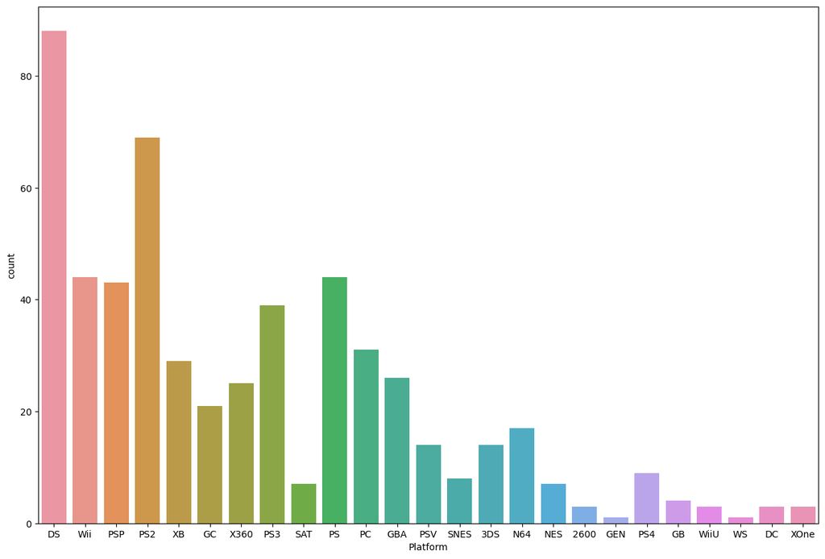

```python
graph = sns.countplot(x="Platform", data = df)
graph.figure.set_figwidth(15)
graph.figure.set_figheight(10)
```

Отобразить среднее значение атрибутов (barplot): Теперь построим гистограмму распределения мировых продаж по всем игровым платформам.

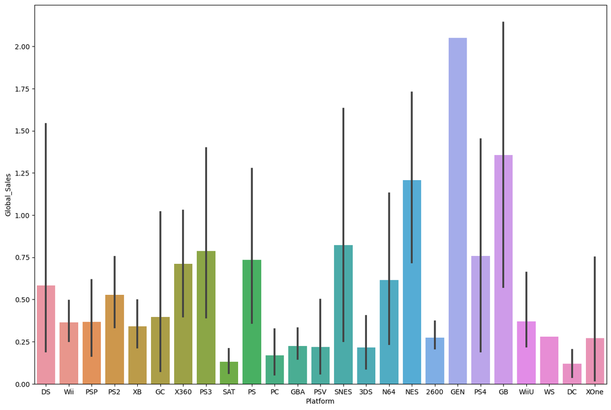

```python
graph = sns.barplot(x=df["Platform"], y=df["Global_Sales"])
graph.figure.set_figwidth(15)
graph.figure.set_figheight(10)
```

Видим, что по данным гистограммы платформа GEN имеет самые групные мировые продажи, второе место по продажам занимает платформа GB, третье метсо занимает платформа NES, а наихудшие мировые продажи были у платформы DC и SAT.

Реализовать ящик с усами (boxplot): Построим диаграмму размаха для мировых продаж видеоигр за всё время наблюдений по различным жанрам.

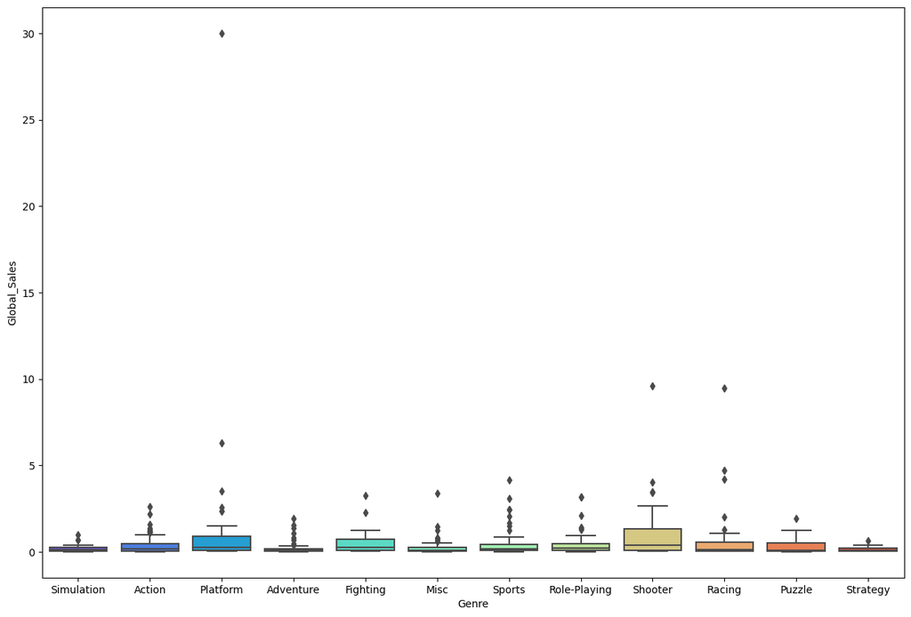

```python
graph = sns.boxplot(x="Genre", y="Global_Sales",data = df,palette='rainbow')
graph.figure.set_figwidth(15)
graph.figure.set_figheight(10)
```

Из диаграммы видим, что самые продаваемые игры это Shooter, второе метсо занимает Platform, на третьем месте располагается Fighting, ну и самая не продаваемая игра это Adventure.

Сделать тепловую карту корреляции (heatmap): Данный метод сообщает, как переменные в наборе данных связаны друг с другом и как они перемещаются относительно друг друга. Значение корреляции колеблется от -1 до +1. 0 Корреляция означает, что две переменные не зависят друг от друга. Положительная корреляция указывает на то, что переменные движутся в одном направлении, а отрицательная корреляция указывает на противоположное.

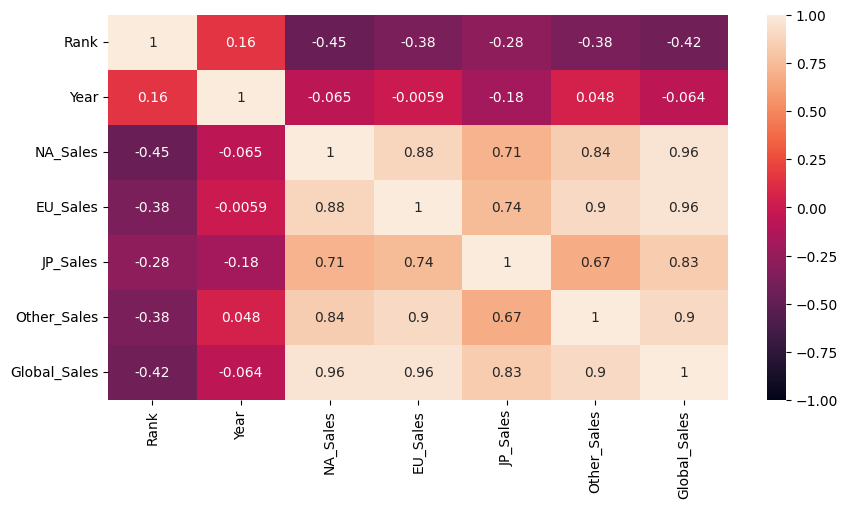

```python
HeatMap = sns.heatmap(df.corr(numeric_only = True), vmin=-1, vmax=1, annot=True) #аргумент annot=True отображает коэффициент корреляции
HeatMap.figure.set_figwidth(10)
HeatMap.figure.set_figheight(5)
```

Показать соотношение между атрибутами (piarplot или pairgrid):

1. pairplot() - построение попарных взаимосвязей в наборе данных.

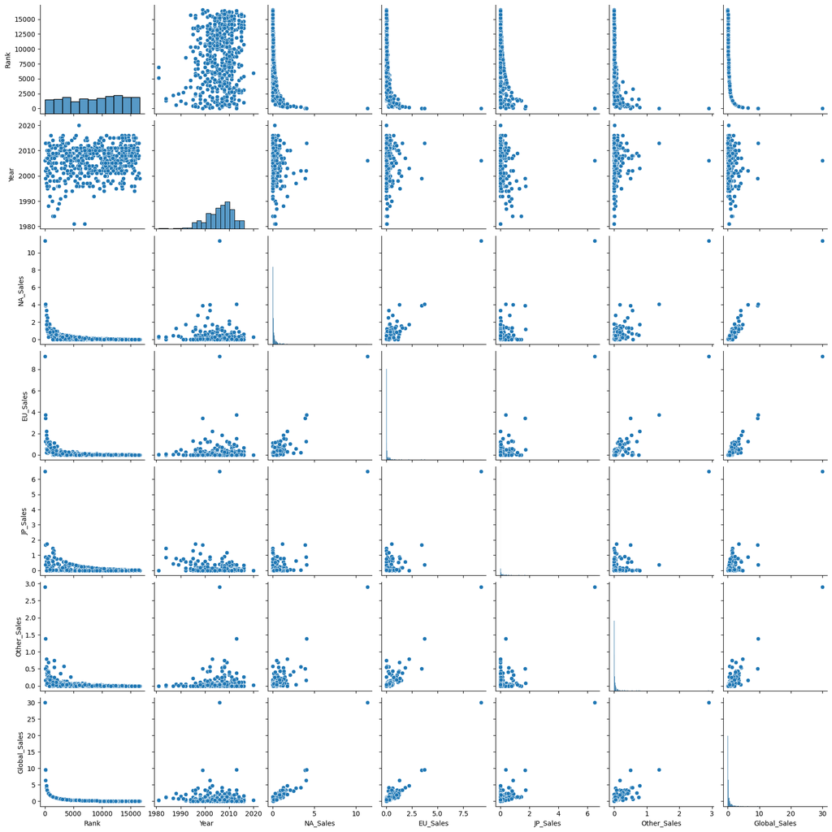

```python
graph = sns.pairplot(df)
```

В данном случае график демонстрирует сравнение абсолютно всех цифровых столбцов друг с другом. Например Rank и Global_Sales, здесь видно каое соотношение продаж было. И так происходит со всеми данными.

2. PairGrid() - сетка подзаголовков для построения попарных взаимосвязей в наборе данных.

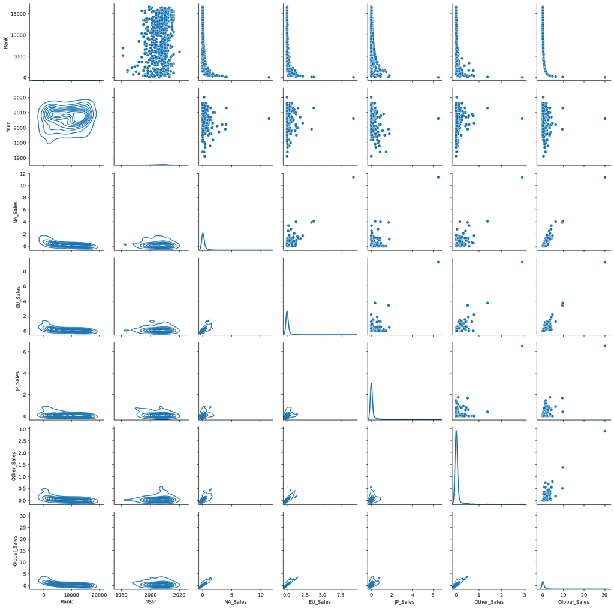

```python
graph = sns.PairGrid(df)
graph = graph.map_upper(sns.scatterplot)
graph = graph.map_lower(sns.kdeplot)
graph = graph.map_diag(sns.kdeplot, lw = 2)
```

В данной сетке происходит все тоже самое, как и в предыдущей, но отличие только в отображении.Здесь также происходит сравнение всех цифровых столбцов друг с другом. Поэтому, Rank и Global_Sales, здесь видно каое соотношение продаж было.

Провести кластеризацию через Kmeans:

Сначала выбираем несколько столбцов и берем значения кратные 50 для демонстрации.

```python
df_mini = df[["NA_Sales","EU_Sales","JP_Sales"]][::50]
df_mini
```

|  | NA_Sales | EU_Sales | JP_Sales |
| --- | --- | --- | --- |
| 0 | 0.21 | 0.00 | 0.00 |
| 50 | 0.02 | 0.01 | 0.00 |
| 100 | 0.19 | 0.15 | 0.00 |
| 150 | 0.14 | 0.05 | 0.00 |
| 200 | 0.23 | 0.01 | 0.00 |
| 250 | 0.11 | 0.03 | 0.00 |
| 300 | 0.03 | 0.02 | 0.00 |
| 350 | 0.00 | 0.00 | 0.08 |
| 400 | 0.06 | 0.04 | 0.00 |
| 450 | 0.09 | 0.07 | 0.00 |
| 500 | 0.00 | 0.00 | 0.05 |
| 550 | 0.00 | 0.21 | 1.18 |

Переходим к самой кластеризации.

```python
from sklearn.cluster import KMeans
model = KMeans(n_clusters=3)

model.fit(df_mini)

all_predictions = model.predict(df_mini)

df_mini["KMeans"] = all_predictions

df_mini
```

|  | NA_Sales | EU_Sales | JP_Sales | KMeans |
| --- | --- | --- | --- | --- |
| 0 | 0.21 | 0.00 | 0.00 | 2 |
| 50 | 0.02 | 0.01 | 0.00 | 0 |
| 100 | 0.19 | 0.15 | 0.00 | 2 |
| 150 | 0.14 | 0.05 | 0.00 | 2 |
| 200 | 0.23 | 0.01 | 0.00 | 2 |
| 250 | 0.11 | 0.03 | 0.00 | 2 |
| 300 | 0.03 | 0.02 | 0.00 | 0 |
| 350 | 0.00 | 0.00 | 0.08 | 0 |
| 400 | 0.06 | 0.04 | 0.00 | 0 |
| 450 | 0.09 | 0.07 | 0.00 | 2 |
| 500 | 0.00 | 0.00 | 0.05 | 0 |
| 550 | 0.00 | 0.21 | 1.18 | 1 |

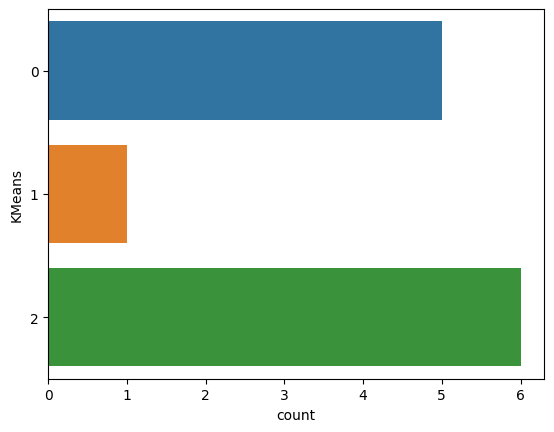

```python
sns.countplot(data = df_mini, y = "KMeans")
```

Демонстрация KMeans на самой простой диаграмме,отображающей количество.

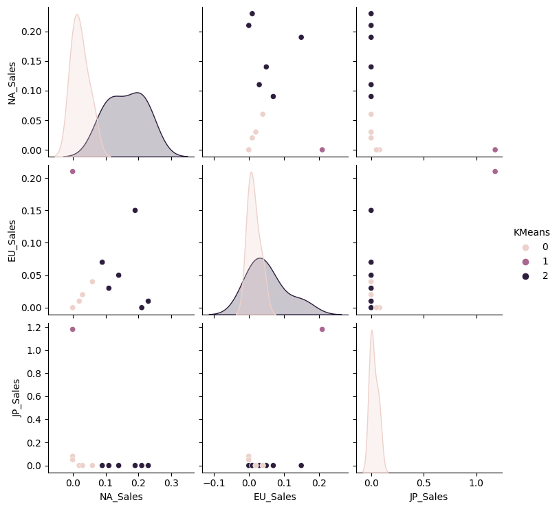

```python
sns.pairplot(df_mini,hue="KMeans")
```

Диаграмма, отображающая нахождения подмножеств из нового столбца в столбцах указанных параметре.

Вывод: В ходе данной практической работы были составлены графики, проведен анализ данных графиков, а также проведена кластеризация.